# Introduction to using the nanostringr package

Aline Talhouk

The dataset expQC is the annotation file for all of the experiments, run in different CodeSets, including:

- Hodgkin Lymphoma Clinical Samples (HL) TOTAL 74 samples
  - HL1 n=32 Unique Samples
  - HL2 n=32 Replicates of HL1 samples
  - HL3 n=10 Replicates (subset of HL1 samples)
- Ovarian Cancer Clinical Samples (OC) TOTAL 258 samples
  - OC1 n=129 Unique
  - OC2 n=129 Replicates of OC1 samples
- Ovarian Cancer Cell Lines (OVCL) TOTAL 26
  - OC1 n=13 Unique
  - OC2 n=13 Replicates of OC1 samples
- DNA Oligonucleotides for the HL CodeSet (HLO) TOTAL 68 HLO pool run at different concentrations
  - HL1 n=36
  - HL2 n=30
  - HL3 n=2
- DNA Oligonucleotides for the OC CodeSet (OVO) TOTAL 135 OVO pool run at different concentrations
  - OC1 n=47
  - OC2 n=88

The NanoStringQC function computes several QC metrics and appends them to the annotation matrix. Care should be taken to ensure that the data is in the proper format.

```r
library(nanostringr)
expOVD <- NanoStringQC(ovd.r,subset(expQC,OVD=="Yes"))
expOVO <- NanoStringQC(ovo.r,subset(expQC,OVO=="Yes"))
expOVCL <- NanoStringQC(ovc.r,subset(expQC,OVCL=="Yes"))
expHLD <- NanoStringQC(hld.r,subset(expQC,HLD=="Yes"))
expHLO <- NanoStringQC(hlo.r,subset(expQC,HLO=="Yes"))
expQC <- rbind(expHLD,expOVD,expHLO,expOVO,expOVCL)
expQC$cohort <- factor(c(rep("HLD", nrow(expHLD)),
                rep("OVD", nrow(expOVD)),rep("HLO",nrow(expHLO)),
                rep("OVO", nrow(expOVO)), rep("OVCL", nrow(expOVCL))))
expQC <- expQC %>%
  mutate(cohort = factor(stringr::str_replace_all(cohort,
                                                   c("HLD" = "HL",
                                                     "OVD" = "OC")),
                          levels = c("HL", "OC", "OVCL", "HLO", "OVO")))
```

# Metrics for Quality Assurance

## Fields Of View (FOV)

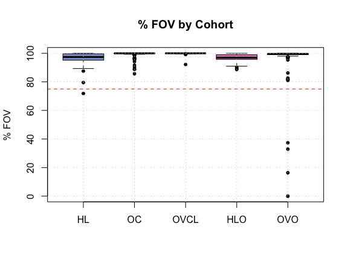

Samples that failed imaging QC based on percent fields of view (FOV) counted across cohorts

## Postive Controls

### Linearity of Positive Controls

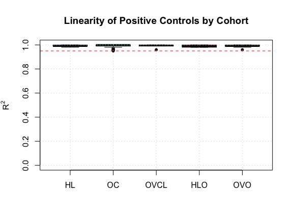

Plot of $R^2$ of postive control probles from samples across all cohorts.

## Signal to Noise Ratio (SNR)

### Level of Housekeeping Genes

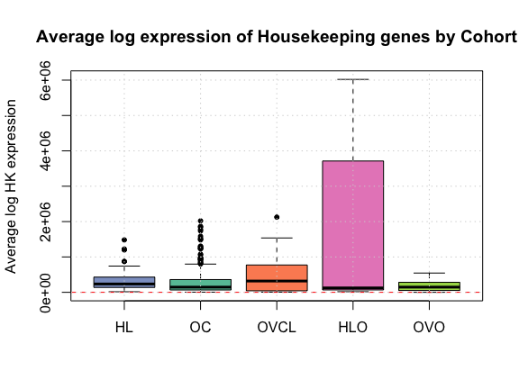

### Limit of Detection (LOD)

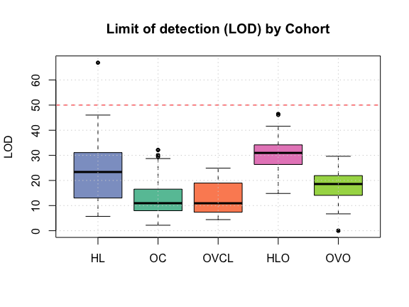

Limit of detection by cohort.

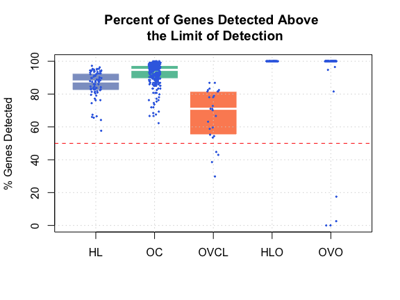

Percent genes of total (excluding controls) detected above the limit of detection

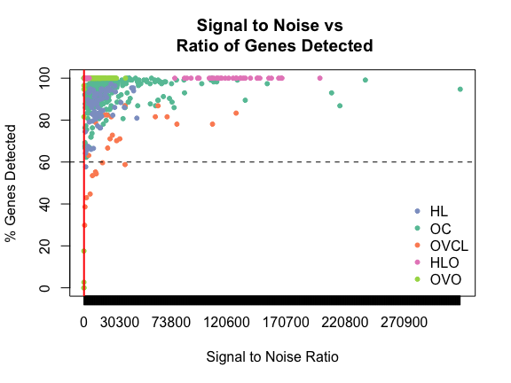

Signal to Noise versus % Gene Detected by cohort

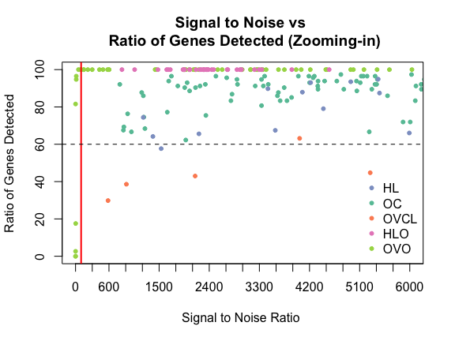

Signal to Noise versus % Gene Detected by cohort zoomed in to the area of possible failures

## Binding Density (BD)

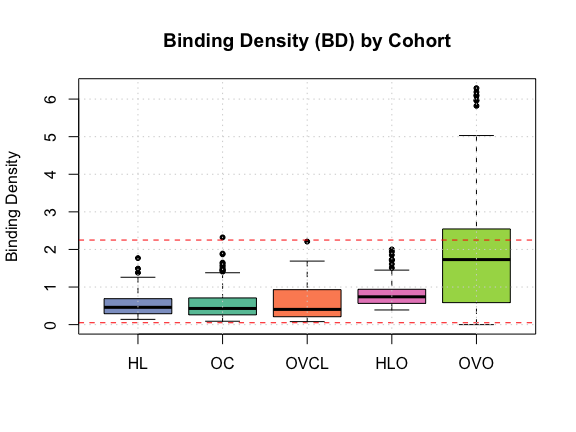

Binding density by cohort. Samples outside of the dashed lines are flagged for having failed the binding density QC measure

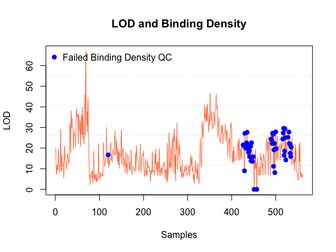

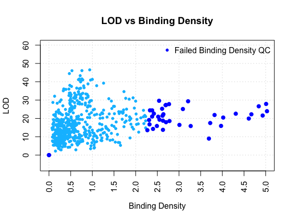

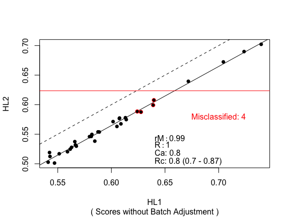

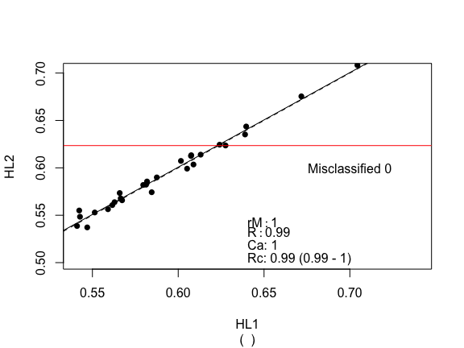

```
## Accuracy
## 0.98 0.99    1
##    1  154 1345
```